# Pertemuan 4

Nadila Putri Fauziyyah

2023-09-21

## White Noise

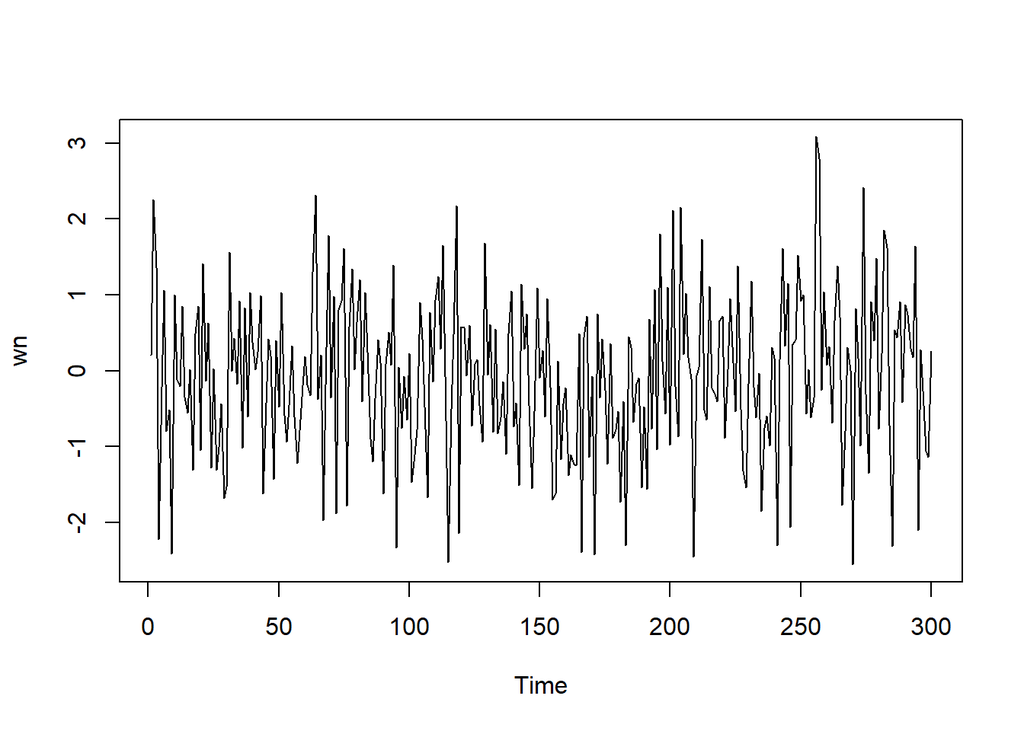

```r
wn <- rnorm(300)
ts.plot(wn)
```

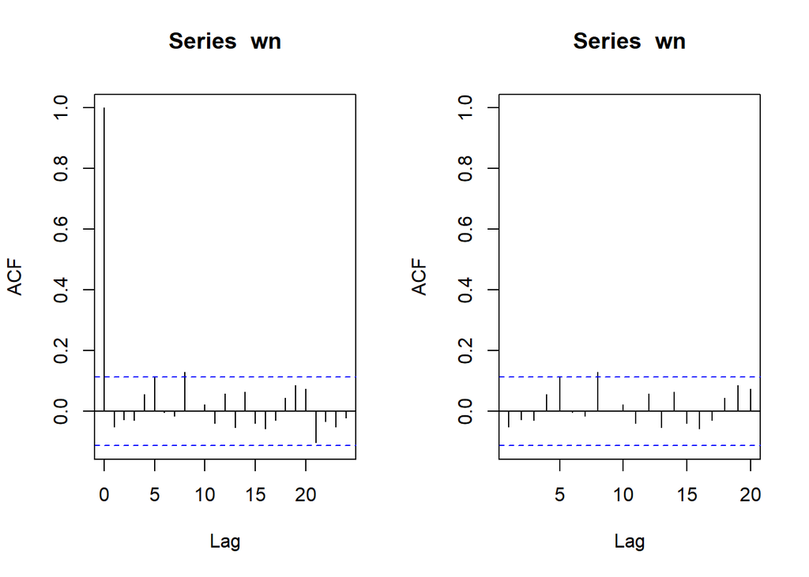

```r
par(mfrow = c(1, 2))
acf(wn)
acf(wn, xlim = c(1, 20))
```

## Proses MA

### Pembangkitan Proses MA(2) Manual

```r
set.seed(028)
ma <- wn[c(1,2)]
```

Rumus MA(2) yang hendak dibangkitkan:

$$y_t = e_t+0.4e_{t-1}+0.6e_{t-2}$$

```r
for(i in 3:300){
   ma[i] <- wn[i] + 0.4 * wn[i - 1] + 0.6 * wn[i - 2]
}
ma
```

```
##   [1]  0.212608160  2.257292197  2.389836056 -0.321903654 -0.288140850
##   [6] -0.355954585 -0.495803926 -0.196657541 -3.096031367 -0.276825441
##  [11] -1.157572168  0.356350112  0.704282441 -0.127024641 -0.181587304
##  [16] -0.407906620 -1.632939478 -0.023302398  0.258789068 -0.408856696
##  [21]  1.509541499 -0.188365550  1.425188687 -1.106046538 -0.110739113
##  [26] -2.066295230 -1.516530721 -1.627104222 -2.458965945 -2.462218772
##  [31] -0.054001038 -0.294791067  1.369137091  0.001431357  1.111221250
##  [36] -0.744659681  0.974365053 -0.879417625  1.285033236  0.426844580
##  [41]  0.787646157  0.480799338  1.103774838 -1.075132235 -0.471357232
##  [46] -0.719711659  0.111561832 -1.091810991 -0.054916057 -1.167367463
##  [51]  1.083416187 -0.449580121 -0.542479268 -1.178938395 -0.414696687
##  [56] -0.751615141 -1.266762746 -1.640797849 -1.243541167 -0.363692448
##  [61] -0.227315368 -0.283121914  1.062672033  2.645908743  1.338709382
##  [66]  1.454369826 -2.106755653 -0.840639935  0.533240830  0.248619932
##  [71]  1.907284003 -1.697718550  0.634264285  0.115052333  2.460074077
```

[output cut: 45 more lines]

### Pembangkitan Proses MA(2) dengan fungsi arima.sim

```r
ma2 <- arima.sim(list(order=c(0,0,2), ma=c(0.4,0.6)), n=300)
ma2
```

```
## Time Series:
## Start = 1
## End = 300
## Frequency = 1
##   [1] -2.4981793130 -2.3910353660 -1.3640272210 -0.4955307869  0.6056793086
##   [6]  0.4576583656 -0.1257094011  1.7293427525 -0.1063134910  2.3627970855
##  [11]  0.2684188696  0.1767258387 -2.1292884563 -0.1185886649  0.6716508056
##  [16]  0.7541797189  0.7819748565  0.1799587866  0.0465224749 -0.4680368791
##  [21] -0.9190599824  0.1233707200 -1.5992900969 -0.5847078692 -0.4670195011
##  [26] -1.6475446336 -0.5756942419 -1.9931843277 -1.4871247355  0.8642279090
##  [31]  0.4953759105  2.8414880623  0.7826040505  2.1183815242 -0.3342878847
##  [36] -0.4165639483 -0.4170420802 -0.9636610243  0.5080406000  0.1282976631
##  [41]  0.7416011718  0.2443157483  0.5238044245 -1.2700368445  1.8482970386
##  [46] -2.0558223768 -0.4444794157 -1.2852054444  0.2469357752 -0.3376195143
##  [51]  0.4241094726 -1.7642820783 -2.7141573333 -2.0023328076 -2.1966371132
```

[output cut: 49 more lines]

## Karakteristik MA(2)

### Plot Time Series

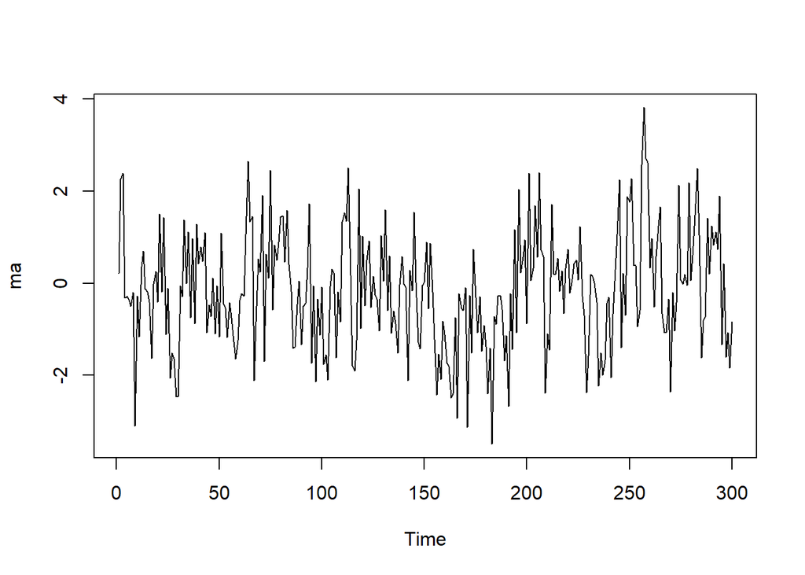

```r
ts.plot(ma)
```

Berdasarkan plot time series, terlihat bahwa data MA(2) yang dibangkitkan stasioner dalam rataan.

### Plot ACF

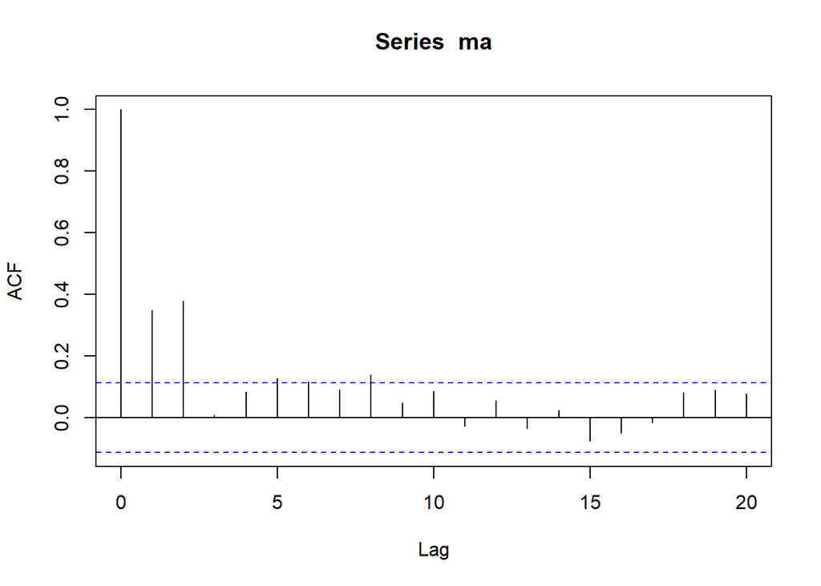

```r
acf(ma,lag.max = 20)
```

Berdasarkan plot AFC tersebut, terlihat bahwa plot ACF *cuts off* di lag kedua

### Plot PACF

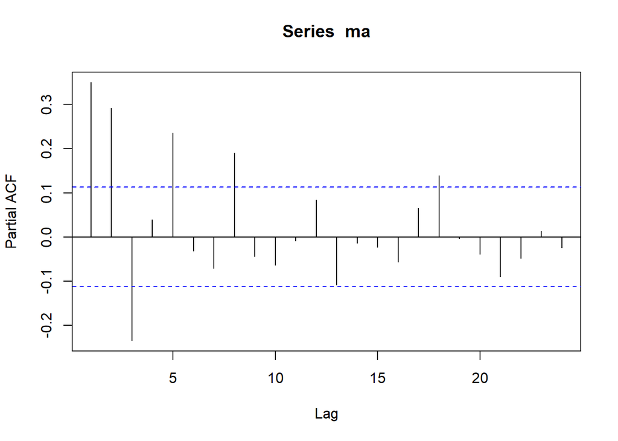

```r
pacf(ma)
```

Berdasarkan plot PACF tersebut, terlihat bahwa plot PACF cenderung *tails off* dan membentuk gelombang sinus

### Plot EACF

```r
TSA::eacf(ma)
```

```
## AR/MA
##   0 1 2 3 4 5 6 7 8 9 10 11 12 13
## 0 x x o o x o o x o o o  o  o  o
## 1 x x o o o o o x o o o  o  o  o
## 2 x x x x o o o o o o o  o  o  o
## 3 x x x x o o o o o o o  o  o  o
## 4 x x x x o o o o o o o  o  o  o
## 5 o x x x o x o o o o o  o  o  o
## 6 x o x x x o o x o o o  o  o  o
## 7 x x x o x o x x x o o  o  o  o
```

Berdasarkan pola segitiga nol pada plot EACF, terlihat bahwa segitiga nol berada pada ordo AR(0) dan ordo MA(2)

## Autokorelasi

### Korelasi antara $Y_t$ dengan $Y_{t-1}$

```r
#Yt
yt_ma <- ma[-1]
yt_ma
```

```
##   [1]  2.257292197  2.389836056 -0.321903654 -0.288140850 -0.355954585
##   [6] -0.495803926 -0.196657541 -3.096031367 -0.276825441 -1.157572168
##  [11]  0.356350112  0.704282441 -0.127024641 -0.181587304 -0.407906620
##  [16] -1.632939478 -0.023302398  0.258789068 -0.408856696  1.509541499
##  [21] -0.188365550  1.425188687 -1.106046538 -0.110739113 -2.066295230
##  [26] -1.516530721 -1.627104222 -2.458965945 -2.462218772 -0.054001038
##  [31] -0.294791067  1.369137091  0.001431357  1.111221250 -0.744659681
##  [36]  0.974365053 -0.879417625  1.285033236  0.426844580  0.787646157
##  [41]  0.480799338  1.103774838 -1.075132235 -0.471357232 -0.719711659
##  [46]  0.111561832 -1.091810991 -0.054916057 -1.167367463  1.083416187
##  [51] -0.449580121 -0.542479268 -1.178938395 -0.414696687 -0.751615141
##  [56] -1.266762746 -1.640797849 -1.243541167 -0.363692448 -0.227315368
##  [61] -0.283121914  1.062672033  2.645908743  1.338709382  1.454369826
##  [66] -2.106755653 -0.840639935  0.533240830  0.248619932  1.907284003
##  [71] -1.697718550  0.634264285  0.115052333  2.460074077 -0.575972397
```

[output cut: 45 more lines]

```r
#Yt-1
yt_1_ma <- ma[-300]
yt_1_ma
```

```
##   [1]  0.212608160  2.257292197  2.389836056 -0.321903654 -0.288140850
##   [6] -0.355954585 -0.495803926 -0.196657541 -3.096031367 -0.276825441
##  [11] -1.157572168  0.356350112  0.704282441 -0.127024641 -0.181587304
##  [16] -0.407906620 -1.632939478 -0.023302398  0.258789068 -0.408856696
##  [21]  1.509541499 -0.188365550  1.425188687 -1.106046538 -0.110739113
##  [26] -2.066295230 -1.516530721 -1.627104222 -2.458965945 -2.462218772
##  [31] -0.054001038 -0.294791067  1.369137091  0.001431357  1.111221250
##  [36] -0.744659681  0.974365053 -0.879417625  1.285033236  0.426844580
##  [41]  0.787646157  0.480799338  1.103774838 -1.075132235 -0.471357232
##  [46] -0.719711659  0.111561832 -1.091810991 -0.054916057 -1.167367463
##  [51]  1.083416187 -0.449580121 -0.542479268 -1.178938395 -0.414696687
##  [56] -0.751615141 -1.266762746 -1.640797849 -1.243541167 -0.363692448
##  [61] -0.227315368 -0.283121914  1.062672033  2.645908743  1.338709382
##  [66]  1.454369826 -2.106755653 -0.840639935  0.533240830  0.248619932
##  [71]  1.907284003 -1.697718550  0.634264285  0.115052333  2.460074077
```

[output cut: 45 more lines]

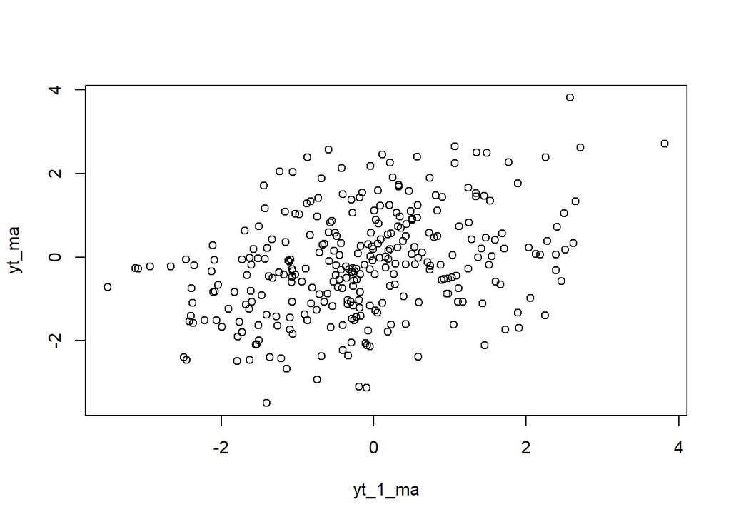

```r
plot(y=yt_ma,x=yt_1_ma)
```

Berdasarkan scatterplot tersebut, terlihat bahwa terdapat hubungan positif antara $Y_t$ dengan $Y_{t-1}$.

```r
cor(yt_ma,yt_1_ma)
```

```
## [1] 0.3500378
```

### Korelasi antara $Y_t$ dengan $Y_{t-2}$

```r
#Yt
yt_ma2 <- ma[-c(1,2)]
yt_ma2
```

```
##   [1]  2.389836056 -0.321903654 -0.288140850 -0.355954585 -0.495803926
##   [6] -0.196657541 -3.096031367 -0.276825441 -1.157572168  0.356350112
##  [11]  0.704282441 -0.127024641 -0.181587304 -0.407906620 -1.632939478
##  [16] -0.023302398  0.258789068 -0.408856696  1.509541499 -0.188365550
##  [21]  1.425188687 -1.106046538 -0.110739113 -2.066295230 -1.516530721
##  [26] -1.627104222 -2.458965945 -2.462218772 -0.054001038 -0.294791067
##  [31]  1.369137091  0.001431357  1.111221250 -0.744659681  0.974365053
##  [36] -0.879417625  1.285033236  0.426844580  0.787646157  0.480799338
##  [41]  1.103774838 -1.075132235 -0.471357232 -0.719711659  0.111561832
##  [46] -1.091810991 -0.054916057 -1.167367463  1.083416187 -0.449580121
##  [51] -0.542479268 -1.178938395 -0.414696687 -0.751615141 -1.266762746
##  [56] -1.640797849 -1.243541167 -0.363692448 -0.227315368 -0.283121914
##  [61]  1.062672033  2.645908743  1.338709382  1.454369826 -2.106755653
##  [66] -0.840639935  0.533240830  0.248619932  1.907284003 -1.697718550
##  [71]  0.634264285  0.115052333  2.460074077 -0.575972397  0.833067047
```

[output cut: 45 more lines]

```r
#Yt-2
yt_2_ma <- ma[-c(299,300)]
yt_2_ma
```

```
##   [1]  0.212608160  2.257292197  2.389836056 -0.321903654 -0.288140850
##   [6] -0.355954585 -0.495803926 -0.196657541 -3.096031367 -0.276825441
##  [11] -1.157572168  0.356350112  0.704282441 -0.127024641 -0.181587304
##  [16] -0.407906620 -1.632939478 -0.023302398  0.258789068 -0.408856696
##  [21]  1.509541499 -0.188365550  1.425188687 -1.106046538 -0.110739113
##  [26] -2.066295230 -1.516530721 -1.627104222 -2.458965945 -2.462218772
##  [31] -0.054001038 -0.294791067  1.369137091  0.001431357  1.111221250
##  [36] -0.744659681  0.974365053 -0.879417625  1.285033236  0.426844580
##  [41]  0.787646157  0.480799338  1.103774838 -1.075132235 -0.471357232
##  [46] -0.719711659  0.111561832 -1.091810991 -0.054916057 -1.167367463
##  [51]  1.083416187 -0.449580121 -0.542479268 -1.178938395 -0.414696687
##  [56] -0.751615141 -1.266762746 -1.640797849 -1.243541167 -0.363692448
##  [61] -0.227315368 -0.283121914  1.062672033  2.645908743  1.338709382
##  [66]  1.454369826 -2.106755653 -0.840639935  0.533240830  0.248619932
##  [71]  1.907284003 -1.697718550  0.634264285  0.115052333  2.460074077
```

[output cut: 45 more lines]

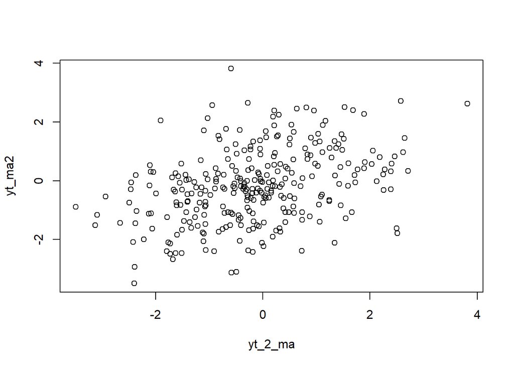

```r
plot(y=yt_ma2,x=yt_2_ma)
```

```r
cor(yt_ma2,yt_2_ma)
```

```
## [1] 0.3828223
```

### Korelasi antara $Y_t$ dengan $Y_{t-3}$

```r
#Yt
yt_ma3 <- ma[-c(1,2,3)]
yt_ma3
```

```
##   [1] -0.321903654 -0.288140850 -0.355954585 -0.495803926 -0.196657541
##   [6] -3.096031367 -0.276825441 -1.157572168  0.356350112  0.704282441
##  [11] -0.127024641 -0.181587304 -0.407906620 -1.632939478 -0.023302398
##  [16]  0.258789068 -0.408856696  1.509541499 -0.188365550  1.425188687
##  [21] -1.106046538 -0.110739113 -2.066295230 -1.516530721 -1.627104222
##  [26] -2.458965945 -2.462218772 -0.054001038 -0.294791067  1.369137091
##  [31]  0.001431357  1.111221250 -0.744659681  0.974365053 -0.879417625
##  [36]  1.285033236  0.426844580  0.787646157  0.480799338  1.103774838
##  [41] -1.075132235 -0.471357232 -0.719711659  0.111561832 -1.091810991
##  [46] -0.054916057 -1.167367463  1.083416187 -0.449580121 -0.542479268
##  [51] -1.178938395 -0.414696687 -0.751615141 -1.266762746 -1.640797849
##  [56] -1.243541167 -0.363692448 -0.227315368 -0.283121914  1.062672033
##  [61]  2.645908743  1.338709382  1.454369826 -2.106755653 -0.840639935
##  [66]  0.533240830  0.248619932  1.907284003 -1.697718550  0.634264285
##  [71]  0.115052333  2.460074077 -0.575972397  0.833067047  0.502445700
```

[output cut: 45 more lines]

```r
#Yt-2
yt_3_ma <- ma[-c(298,299,300)]
yt_3_ma
```

```
##   [1]  0.212608160  2.257292197  2.389836056 -0.321903654 -0.288140850
##   [6] -0.355954585 -0.495803926 -0.196657541 -3.096031367 -0.276825441
##  [11] -1.157572168  0.356350112  0.704282441 -0.127024641 -0.181587304
##  [16] -0.407906620 -1.632939478 -0.023302398  0.258789068 -0.408856696
##  [21]  1.509541499 -0.188365550  1.425188687 -1.106046538 -0.110739113
##  [26] -2.066295230 -1.516530721 -1.627104222 -2.458965945 -2.462218772
##  [31] -0.054001038 -0.294791067  1.369137091  0.001431357  1.111221250
##  [36] -0.744659681  0.974365053 -0.879417625  1.285033236  0.426844580
##  [41]  0.787646157  0.480799338  1.103774838 -1.075132235 -0.471357232
##  [46] -0.719711659  0.111561832 -1.091810991 -0.054916057 -1.167367463
##  [51]  1.083416187 -0.449580121 -0.542479268 -1.178938395 -0.414696687
##  [56] -0.751615141 -1.266762746 -1.640797849 -1.243541167 -0.363692448
##  [61] -0.227315368 -0.283121914  1.062672033  2.645908743  1.338709382
##  [66]  1.454369826 -2.106755653 -0.840639935  0.533240830  0.248619932
##  [71]  1.907284003 -1.697718550  0.634264285  0.115052333  2.460074077
```

[output cut: 45 more lines]

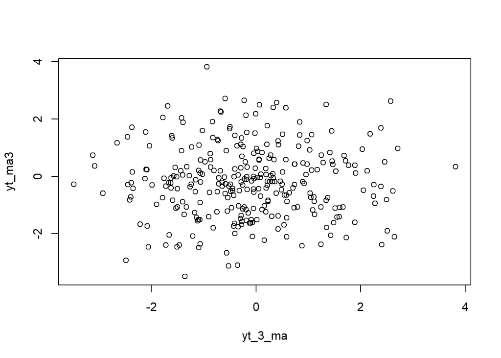

```r
plot(y=yt_ma3,x=yt_3_ma)
```

```r
cor(yt_ma3,yt_3_ma)
```

```
## [1] 0.008027601
```

## Proses AR

### Pembangkitan Proses AR(2) Manual

Membangkitkan proses AR(2) dengan $\phi = 0.5$ dan $\phi = 0.2$ sebanyak 300 observasi dan $c=0$.

```r
set.seed(028)
```

Rumus AR(2) yang hendak dibangkitkan:

$$Y_t = e_t+0.5Y_{t-1}+0.2Y_{t-2}$$

```r
n<-length(wn)
n
```

```
## [1] 300
```

```r
ar <- c(1:n)
for (i in 3:n) {ar[i]<-wn[i]+0.5*ar[i-1]+0.2*ar[i-2]}
ar
```

```
##   [1]  1.000000000  2.000000000  2.559354281 -0.540343544  0.025953940
##   [6]  0.967264145 -0.302476332 -0.475336731 -2.712394926 -0.451866896
##  [11] -0.877204991 -0.728747488  0.309651879 -0.337871880 -0.659493512
##  [16] -0.376063580 -1.629880223 -0.402229865  0.322498745 -0.960642962
##  [21]  1.000544479  0.178099430  0.916545257 -0.785082152 -0.184813258
##  [26] -1.558100996 -1.823723955 -1.662295315 -2.874706655 -3.297217597
##  [31] -0.659300561 -0.993141570 -0.196224439 -0.465763098  0.647379964
##  [36] -0.780511341  0.566301016 -0.476572441  0.905207074  0.734212801
##  [41]  0.566884617  0.677435235  1.445767151 -0.762520876 -0.511311206
##  [46]  0.012345142  0.098792713 -1.370201512 -0.268360941 -0.881140607
##  [51]  0.540152866 -0.485738052 -1.066120391 -1.088881608 -0.430122886
##  [56] -1.040265422 -1.826474169 -1.909504671 -1.516112407 -0.952294789
##  [61] -0.964111041 -0.994337335  0.612254998  2.425364140  0.965253284
##  [66]  1.179158746 -1.186781462 -0.537309886  1.280776851  0.174681688
##  [71]  1.322005270 -1.178236343  0.472111860  0.921234592  2.168685987
```

[output cut: 45 more lines]

### Pembangkitan Proses AR(2) dengan fungsi arima.sim

```r
ar2 <- arima.sim(list(order=c(2,0,0), ar=c(0.5,0.2)), n=300)
ar2
```

```
## Time Series:
## Start = 1
## End = 300
## Frequency = 1
##   [1] -1.107295890 -0.239793390 -2.001561262 -1.334032043 -1.950272275
##   [6] -2.204714041  0.286691432  0.063800552  1.718705823  0.786091582
##  [11]  1.911896700  0.360447748 -0.257939014  0.305926205 -0.515082853
##  [16]  0.340583978  0.350671908  0.549531227  0.296746459  0.617698227
##  [21] -1.016713818  1.801793413 -1.401965370 -1.257262099 -0.567862741
##  [26]  0.125070290 -0.857535379 -0.053317417 -1.618723563 -3.176221216
##  [31] -2.119375080 -2.394843422 -1.571050045  0.577148772 -0.717352476
##  [36] -0.591329443  0.080845569 -0.795511129 -0.886971428 -2.414484225
##  [41] -1.823158164 -2.390031136 -1.918273649 -1.107098590 -0.850900987
##  [46] -0.244325590 -1.055487503 -0.144816306  0.367993683 -0.678867801
##  [51] -1.290672985  1.049219245  2.777950860  1.557718194  1.454602965
```

[output cut: 49 more lines]

## Karakteristik AR(2)

### Plot Time Series

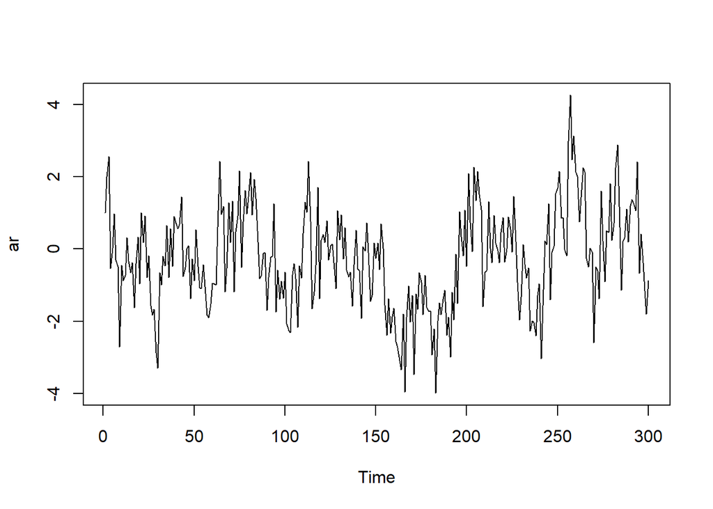

```r
ts.plot(ar)
```

Berdasarkan plot time series tersebut terlihat bahwa data cenderung stasioner pada rataan.

### Plot ACF

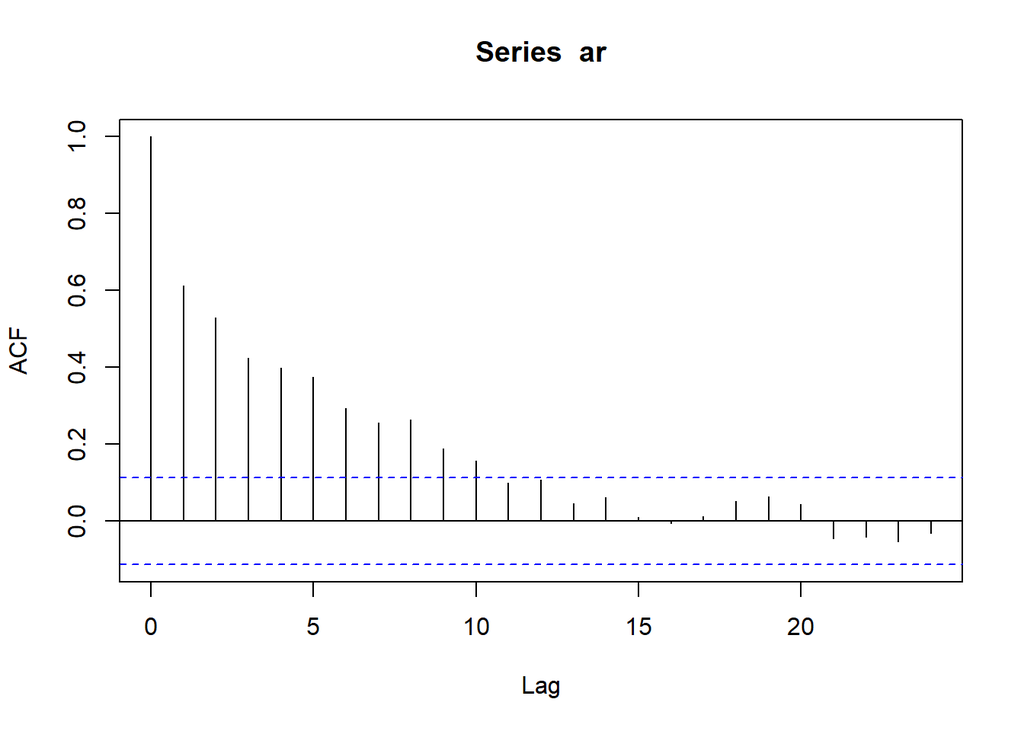

```r
acf(ar)
```

Berdasarkan plot ACF tersebut terlihat bahwa plot ACF cenderung *tails off* dan cenderung membentuk pola grafik sinus

### Plot PACF

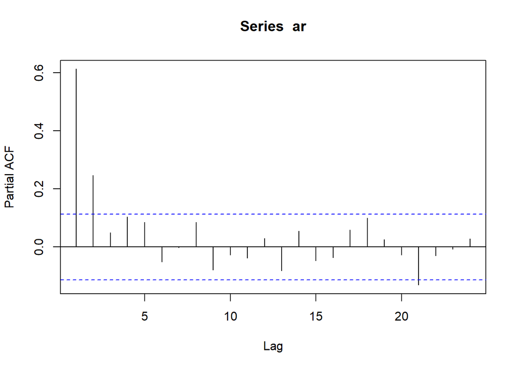

```r
pacf(ar)
```

Berdasarkan plot PACF tersebut, terlihat bahwa plot PACF *cuts off* pada lag kedua

### Plot EACF

```r
TSA::eacf(ar)
```

```
## AR/MA
##   0 1 2 3 4 5 6 7 8 9 10 11 12 13
## 0 x x x x x x x x x x o  o  o  o
## 1 x o o o o o o x o o o  o  o  o
## 2 x x o o o o o x o o o  o  o  o
## 3 x x x o o o o x o o o  o  o  o
## 4 x x x x o o o x o o o  o  o  o
## 5 x x x o o o o o o o o  o  o  o
## 6 x x o x x o o o o o o  o  o  o
## 7 x x o o x o o o o o o  o  o  o
```

## Autokorelasi

### Korelasi antara $Y_t$ dengan $Y_{t-1}$

```r
#Yt
yt_ar <- ar[-1]
yt_ar
```

```
##   [1]  2.000000000  2.559354281 -0.540343544  0.025953940  0.967264145
##   [6] -0.302476332 -0.475336731 -2.712394926 -0.451866896 -0.877204991
##  [11] -0.728747488  0.309651879 -0.337871880 -0.659493512 -0.376063580
##  [16] -1.629880223 -0.402229865  0.322498745 -0.960642962  1.000544479
##  [21]  0.178099430  0.916545257 -0.785082152 -0.184813258 -1.558100996
##  [26] -1.823723955 -1.662295315 -2.874706655 -3.297217597 -0.659300561
##  [31] -0.993141570 -0.196224439 -0.465763098  0.647379964 -0.780511341
##  [36]  0.566301016 -0.476572441  0.905207074  0.734212801  0.566884617
##  [41]  0.677435235  1.445767151 -0.762520876 -0.511311206  0.012345142
##  [46]  0.098792713 -1.370201512 -0.268360941 -0.881140607  0.540152866
##  [51] -0.485738052 -1.066120391 -1.088881608 -0.430122886 -1.040265422
##  [56] -1.826474169 -1.909504671 -1.516112407 -0.952294789 -0.964111041
##  [61] -0.994337335  0.612254998  2.425364140  0.965253284  1.179158746
##  [66] -1.186781462 -0.537309886  1.280776851  0.174681688  1.322005270
##  [71] -1.178236343  0.472111860  0.921234592  2.168685987 -0.505336571
```

[output cut: 45 more lines]

```r
#Yt-1
yt_1_ar <- ar[-300]
yt_1_ar
```

```
##   [1]  1.000000000  2.000000000  2.559354281 -0.540343544  0.025953940
##   [6]  0.967264145 -0.302476332 -0.475336731 -2.712394926 -0.451866896
##  [11] -0.877204991 -0.728747488  0.309651879 -0.337871880 -0.659493512
##  [16] -0.376063580 -1.629880223 -0.402229865  0.322498745 -0.960642962
##  [21]  1.000544479  0.178099430  0.916545257 -0.785082152 -0.184813258
##  [26] -1.558100996 -1.823723955 -1.662295315 -2.874706655 -3.297217597
##  [31] -0.659300561 -0.993141570 -0.196224439 -0.465763098  0.647379964
##  [36] -0.780511341  0.566301016 -0.476572441  0.905207074  0.734212801
##  [41]  0.566884617  0.677435235  1.445767151 -0.762520876 -0.511311206
##  [46]  0.012345142  0.098792713 -1.370201512 -0.268360941 -0.881140607
##  [51]  0.540152866 -0.485738052 -1.066120391 -1.088881608 -0.430122886
##  [56] -1.040265422 -1.826474169 -1.909504671 -1.516112407 -0.952294789
##  [61] -0.964111041 -0.994337335  0.612254998  2.425364140  0.965253284
##  [66]  1.179158746 -1.186781462 -0.537309886  1.280776851  0.174681688
##  [71]  1.322005270 -1.178236343  0.472111860  0.921234592  2.168685987
```

[output cut: 45 more lines]

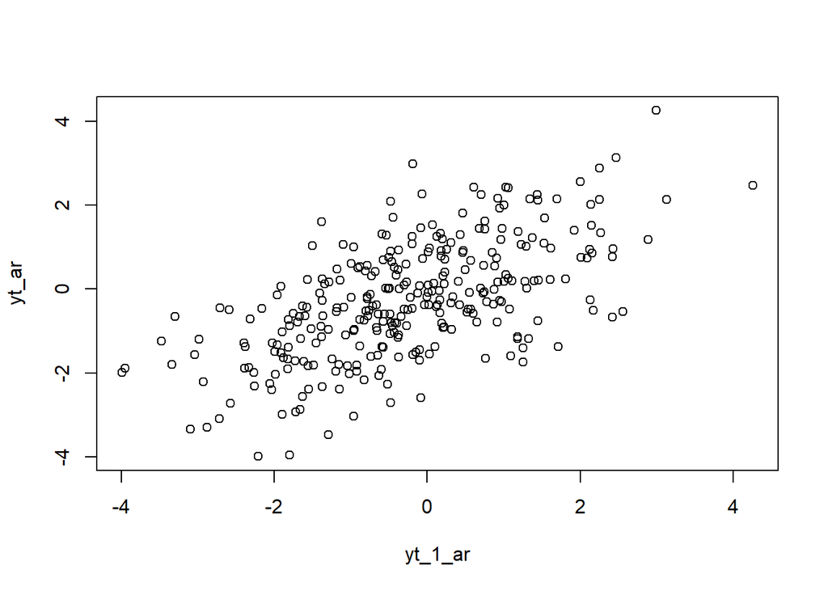

```r
plot(y=yt_ar,x=yt_1_ar)
```

Berdasarkan scatterplot tersebut, terlihat bahwa terdapat hubungan positif antara $Y_t$ dengan $Y_{t-1}$.

```r
cor(yt_ar,yt_1_ar)
```

```
## [1] 0.6134355
```

### Korelasi antara $Y_t$ dengan $Y_{t-2}$

```r
#Yt
yt_ar2 <- ar[-c(1,2)]
yt_ar2
```

```
##   [1]  2.559354281 -0.540343544  0.025953940  0.967264145 -0.302476332
##   [6] -0.475336731 -2.712394926 -0.451866896 -0.877204991 -0.728747488
##  [11]  0.309651879 -0.337871880 -0.659493512 -0.376063580 -1.629880223
##  [16] -0.402229865  0.322498745 -0.960642962  1.000544479  0.178099430
##  [21]  0.916545257 -0.785082152 -0.184813258 -1.558100996 -1.823723955
##  [26] -1.662295315 -2.874706655 -3.297217597 -0.659300561 -0.993141570
##  [31] -0.196224439 -0.465763098  0.647379964 -0.780511341  0.566301016
##  [36] -0.476572441  0.905207074  0.734212801  0.566884617  0.677435235
##  [41]  1.445767151 -0.762520876 -0.511311206  0.012345142  0.098792713
##  [46] -1.370201512 -0.268360941 -0.881140607  0.540152866 -0.485738052
##  [51] -1.066120391 -1.088881608 -0.430122886 -1.040265422 -1.826474169
##  [56] -1.909504671 -1.516112407 -0.952294789 -0.964111041 -0.994337335
##  [61]  0.612254998  2.425364140  0.965253284  1.179158746 -1.186781462
##  [66] -0.537309886  1.280776851  0.174681688  1.322005270 -1.178236343
##  [71]  0.472111860  0.921234592  2.168685987 -0.505336571  0.755518761
```

[output cut: 45 more lines]

```r
#Yt-2
yt_2_ar <- ar[-c(299,300)]
yt_2_ar
```

```
##   [1]  1.000000000  2.000000000  2.559354281 -0.540343544  0.025953940
##   [6]  0.967264145 -0.302476332 -0.475336731 -2.712394926 -0.451866896
##  [11] -0.877204991 -0.728747488  0.309651879 -0.337871880 -0.659493512
##  [16] -0.376063580 -1.629880223 -0.402229865  0.322498745 -0.960642962
##  [21]  1.000544479  0.178099430  0.916545257 -0.785082152 -0.184813258
##  [26] -1.558100996 -1.823723955 -1.662295315 -2.874706655 -3.297217597
##  [31] -0.659300561 -0.993141570 -0.196224439 -0.465763098  0.647379964
##  [36] -0.780511341  0.566301016 -0.476572441  0.905207074  0.734212801
##  [41]  0.566884617  0.677435235  1.445767151 -0.762520876 -0.511311206
##  [46]  0.012345142  0.098792713 -1.370201512 -0.268360941 -0.881140607
##  [51]  0.540152866 -0.485738052 -1.066120391 -1.088881608 -0.430122886
##  [56] -1.040265422 -1.826474169 -1.909504671 -1.516112407 -0.952294789
##  [61] -0.964111041 -0.994337335  0.612254998  2.425364140  0.965253284
##  [66]  1.179158746 -1.186781462 -0.537309886  1.280776851  0.174681688
##  [71]  1.322005270 -1.178236343  0.472111860  0.921234592  2.168685987
```

[output cut: 45 more lines]

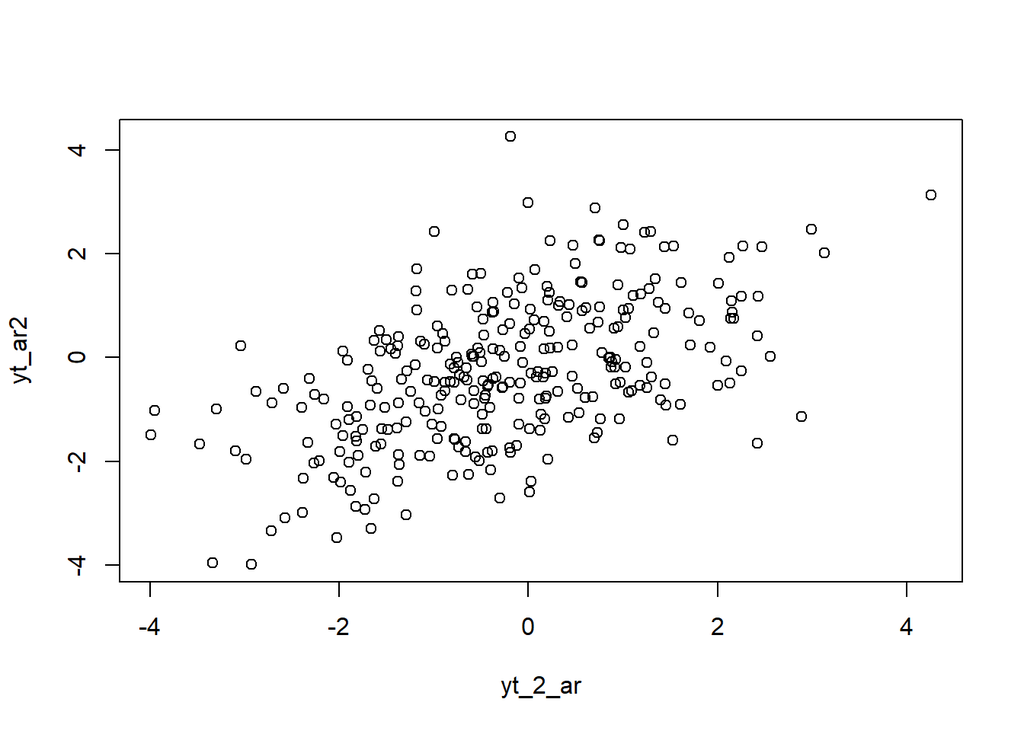

```r
plot(y=yt_ar2,x=yt_2_ar)
```

Berdasarkan scatterplot tersebut, terlihat bahwa terdapat hubungan positif antara $Y_t$ dengan $Y_{t-2}$.

```r
cor(yt_ar2,yt_2_ar)
```

```
## [1] 0.5332075
```

### Korelasi antara $Y_t$ dengan $Y_{t-3}$

```r
#Yt
yt_ar3 <- ar[-c(1,2,3)]
yt_ar3
```

```
##   [1] -0.540343544  0.025953940  0.967264145 -0.302476332 -0.475336731
##   [6] -2.712394926 -0.451866896 -0.877204991 -0.728747488  0.309651879
##  [11] -0.337871880 -0.659493512 -0.376063580 -1.629880223 -0.402229865
##  [16]  0.322498745 -0.960642962  1.000544479  0.178099430  0.916545257
##  [21] -0.785082152 -0.184813258 -1.558100996 -1.823723955 -1.662295315
##  [26] -2.874706655 -3.297217597 -0.659300561 -0.993141570 -0.196224439
##  [31] -0.465763098  0.647379964 -0.780511341  0.566301016 -0.476572441
##  [36]  0.905207074  0.734212801  0.566884617  0.677435235  1.445767151
##  [41] -0.762520876 -0.511311206  0.012345142  0.098792713 -1.370201512
##  [46] -0.268360941 -0.881140607  0.540152866 -0.485738052 -1.066120391
##  [51] -1.088881608 -0.430122886 -1.040265422 -1.826474169 -1.909504671
##  [56] -1.516112407 -0.952294789 -0.964111041 -0.994337335  0.612254998
##  [61]  2.425364140  0.965253284  1.179158746 -1.186781462 -0.537309886
##  [66]  1.280776851  0.174681688  1.322005270 -1.178236343  0.472111860
##  [71]  0.921234592  2.168685987 -0.505336571  0.755518761  1.613713716
```

[output cut: 45 more lines]

```r
#Yt-2
yt_3_ar <- ar[-c(298,299,300)]
yt_3_ar
```

```
##   [1]  1.000000000  2.000000000  2.559354281 -0.540343544  0.025953940
##   [6]  0.967264145 -0.302476332 -0.475336731 -2.712394926 -0.451866896
##  [11] -0.877204991 -0.728747488  0.309651879 -0.337871880 -0.659493512
##  [16] -0.376063580 -1.629880223 -0.402229865  0.322498745 -0.960642962
##  [21]  1.000544479  0.178099430  0.916545257 -0.785082152 -0.184813258
##  [26] -1.558100996 -1.823723955 -1.662295315 -2.874706655 -3.297217597
##  [31] -0.659300561 -0.993141570 -0.196224439 -0.465763098  0.647379964
##  [36] -0.780511341  0.566301016 -0.476572441  0.905207074  0.734212801
##  [41]  0.566884617  0.677435235  1.445767151 -0.762520876 -0.511311206
##  [46]  0.012345142  0.098792713 -1.370201512 -0.268360941 -0.881140607
##  [51]  0.540152866 -0.485738052 -1.066120391 -1.088881608 -0.430122886
##  [56] -1.040265422 -1.826474169 -1.909504671 -1.516112407 -0.952294789
##  [61] -0.964111041 -0.994337335  0.612254998  2.425364140  0.965253284
##  [66]  1.179158746 -1.186781462 -0.537309886  1.280776851  0.174681688
##  [71]  1.322005270 -1.178236343  0.472111860  0.921234592  2.168685987
```

[output cut: 45 more lines]

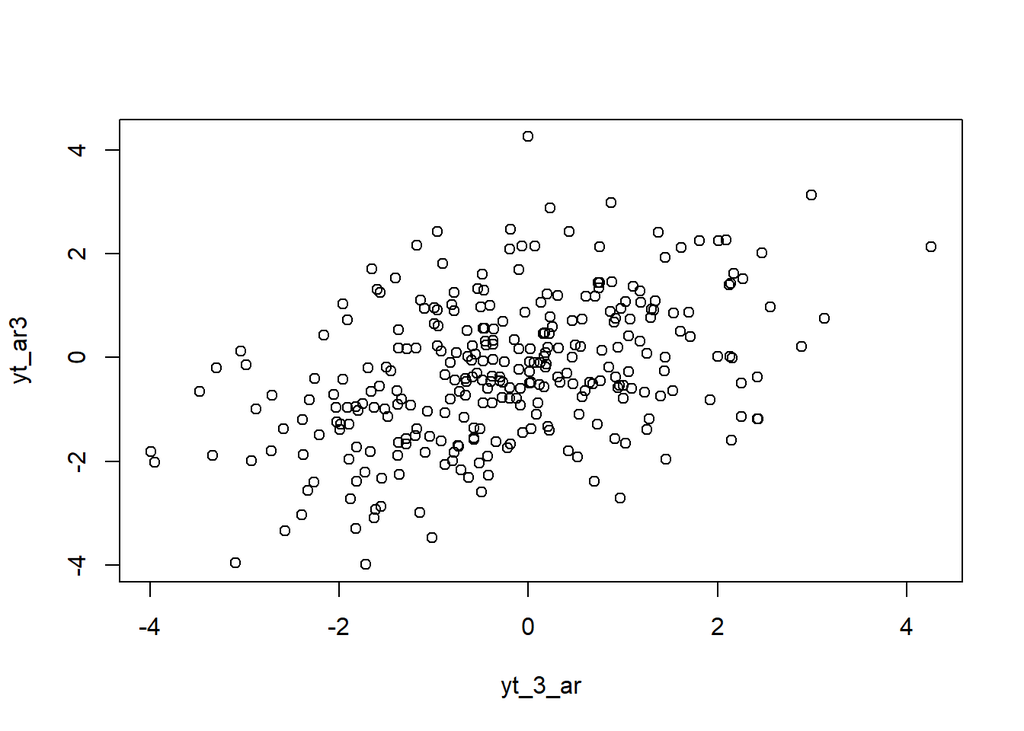

```r
plot(y=yt_ar3,x=yt_3_ar)
```

Berdasarkan scatterplot tersebut, terlihat bahwa terdapat hubungan positif antara $Y_t$ dengan $Y_{t-3}$.

```r
cor(yt_ar3,yt_3_ar)
```

```
## [1] 0.4303581
```

## Fungsi pembangkitan ARMA

Bentuk umum data berpola ARMA.

```r
set.seed(028)
n = length(wn)
phi1 = 0.5
phi2 = 0.2

theta1 = 0.4
theta2 = 0.6

y.arma=c(1:n)
for (i in 5:n){y.arma[i] = phi1*y.arma[i-1] +phi2*y.arma[i-2] + theta1*wn[i-1] + phi2*y.arma[i-2]+wn[i]}
y.arma
```

```
##   [1]  1.000000000  2.000000000  3.000000000  4.000000000  2.096246582
##   [6]  3.624181116  2.284232352  1.757717552 -0.828700135  0.322442349
##  [11]  0.120707728 -0.053957832  0.790862151  0.366686269 -0.191579281
##  [16] -0.148852760 -1.452504802 -0.821850435  0.052831769 -1.003934763
##  [21]  0.518952992  0.294404859  0.930152586 -0.445181772 -0.337700952
##  [26] -1.645833615 -2.489179169 -2.744820490 -4.222421375 -5.408069773
##  [31] -3.439715950 -3.261433827 -2.576015944 -2.588721484 -1.472869744
##  [36] -2.415169608 -1.374071489 -1.925891991 -0.723789772 -0.343234694
##  [41] -0.291626954 -0.028462268  0.961650841 -0.753981941 -1.059891432
##  [46] -0.578715252 -0.350229847 -1.750714967 -1.187294909 -1.608060767
##  [51] -0.433720923 -1.025912988 -1.849561346 -2.166332446 -1.678918286
##  [56] -2.182402981 -3.226056749 -3.762330821 -3.682939149 -3.237165649
##  [61] -3.201434709 -3.291302937 -1.752708621  0.646126972  0.179341895
##  [66]  0.411629098 -1.607276475 -1.606502099  0.268726085 -0.151767323
##  [71]  0.866817924 -1.110069660 -0.161148809  0.714955253  2.274994794
```

[output cut: 45 more lines]

### Pembangkitan Proses ARMA(2,2) manual dengan fungsi arima.sim

```r
arma22 <- arima.sim(list(order=c(2,0,2), ar = c(0.5,0.2), ma =c(0.4,0.6)), n=300)
arma22
```

```
## Time Series:
## Start = 1
## End = 300
## Frequency = 1
##   [1] -2.76039543 -2.27741900 -3.68397291 -3.78459499 -1.76486417 -1.14397517
##   [7]  1.91652764  1.51207284  3.25772347  1.59698842  1.03347495  0.41909308
##  [13] -0.54741949  0.31814947  0.17788850  0.89417532  0.72698111  1.06613004
##  [19] -0.59157560  1.76573525 -1.29126987 -0.73696730 -1.91194307 -0.85642922
##  [25] -1.14822274 -0.32128774 -2.15457050 -3.85570013 -4.36109697 -5.14832563
##  [31] -3.80061204 -1.48817697 -1.42912275 -0.53198098 -0.58609755 -1.11797046
##  [37] -1.15666845 -3.24657941 -3.32113466 -4.56798490 -3.96818097 -3.30842671
##  [43] -2.44470460 -1.24894513 -1.66375832 -0.71360665 -0.32322534 -0.61856011
##  [49] -1.34142389  0.12562937  2.42323477  3.29843009  3.74446076  2.77437022
##  [55]  1.47747344  2.22798858  3.15120117  5.42389536  5.99450882  5.30575978
##  [61]  3.84908134  1.33118863  1.46718023  0.62493128  0.84842223  1.00129482
```

[output cut: 39 more lines]

## Karakteristik ARMA(2,2)

### Plot Time Series

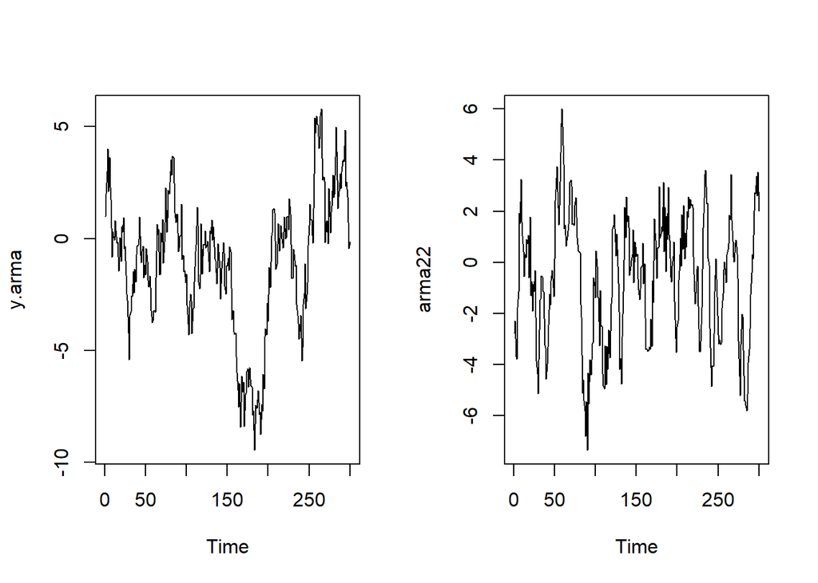

```r
par(mfrow = c(1, 2))
ts.plot(y.arma)
ts.plot(arma22)
```

```r
par(mfrow = c(1, 1))
```

### Plot ACF

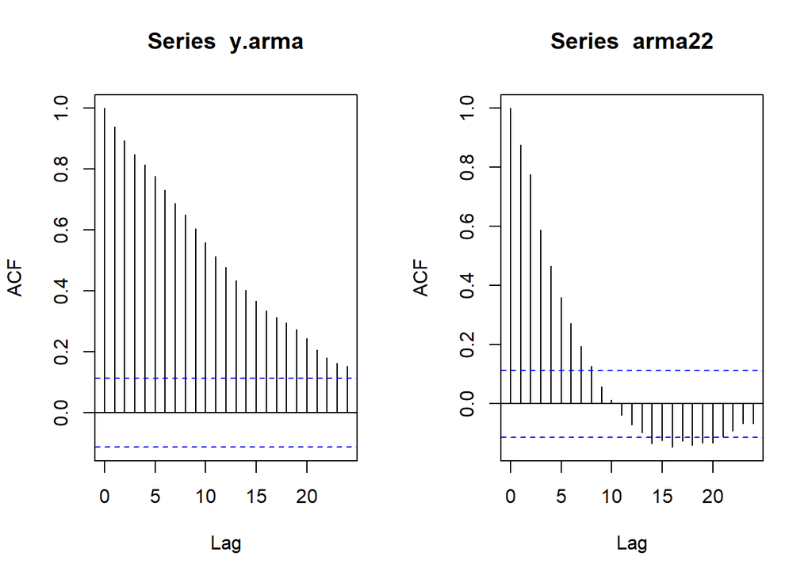

```r
par(mfrow = c(1, 2))
acf(y.arma)
acf(arma22)
```

```r
par(mfrow = c(1, 1))
```

Berdasarkan plot ACF tersebut, terlihat bahwa model ARMA(2,2) hasil simulasi memiliki plot ACF yang *tails off* dan cenderung membentuk pola sinus.

### Plot PACF

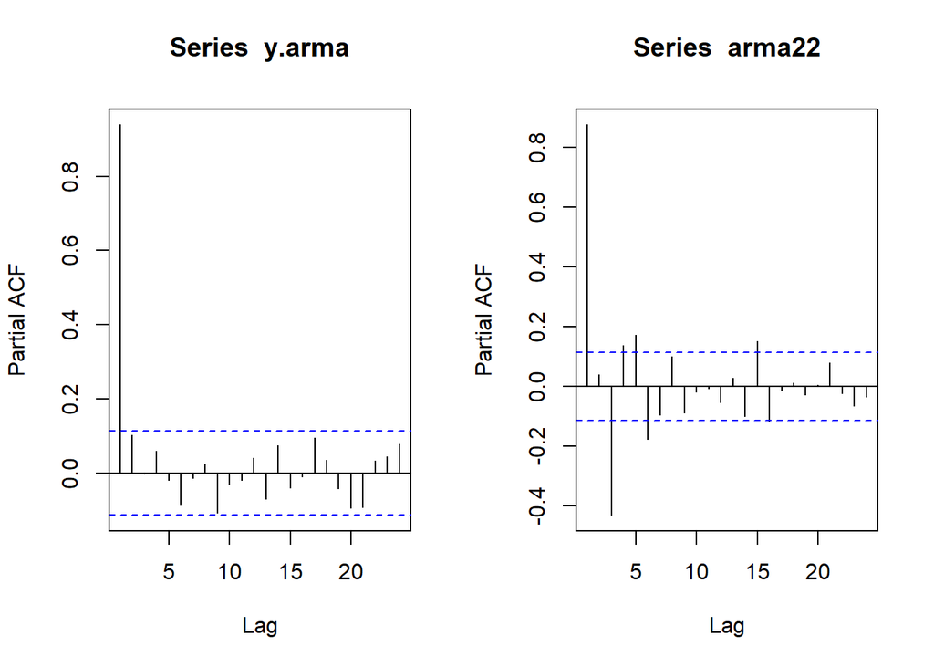

```r
par(mfrow = c(1, 2))
pacf(y.arma)
pacf(arma22)
```

```r
par(mfrow = c(1, 1))
```

Berdasarkan plot PACF tersebut, terlihat bahwa model ARMA(2,2) hasil simulasi memiliki plot PACF yang *tails off*, sesuai dengan teori

### Plot EACF

```r
TSA::eacf(y.arma)
```

```
## AR/MA
##   0 1 2 3 4 5 6 7 8 9 10 11 12 13
## 0 x x x x x x x x x x x  x  x  x
## 1 x o o o o o o x o o o  o  o  o
## 2 o o o o o o o x o o o  o  o  o
## 3 x x o o o o o o o o o  o  o  o
## 4 x x x o o o o x o o o  o  o  o
## 5 x x x o o o o o o o o  o  o  o
## 6 x x x o x o o o o o o  o  o  o
## 7 x o x x x o o o o o o  o  o  o
```

```r
TSA::eacf(arma22)
```

```
## AR/MA
##   0 1 2 3 4 5 6 7 8 9 10 11 12 13
## 0 x x x x x x x x o o o  o  o  x
## 1 o x x o o o o o o o o  o  o  x
## 2 x x o o o o o o o o o  o  o  o
## 3 x x x o o o o o o o o  o  o  o
## 4 x x x x o o o o o o o  o  o  o
## 5 x x x x o o o o o o o  o  o  o
## 6 x x x x x o x o o o o  o  o  o
## 7 x o x x x o o o o o o  o  o  o
```

## Autokorelasi

### Korelasi antara $Y_t$ dengan $Y_{t-1}$

```r
#Yt
yt_arma <- arma22[-1]
yt_arma
```

```
##   [1] -2.27741900 -3.68397291 -3.78459499 -1.76486417 -1.14397517  1.91652764
##   [7]  1.51207284  3.25772347  1.59698842  1.03347495  0.41909308 -0.54741949
##  [13]  0.31814947  0.17788850  0.89417532  0.72698111  1.06613004 -0.59157560
##  [19]  1.76573525 -1.29126987 -0.73696730 -1.91194307 -0.85642922 -1.14822274
##  [25] -0.32128774 -2.15457050 -3.85570013 -4.36109697 -5.14832563 -3.80061204
##  [31] -1.48817697 -1.42912275 -0.53198098 -0.58609755 -1.11797046 -1.15666845
##  [37] -3.24657941 -3.32113466 -4.56798490 -3.96818097 -3.30842671 -2.44470460
##  [43] -1.24894513 -1.66375832 -0.71360665 -0.32322534 -0.61856011 -1.34142389
##  [49]  0.12562937  2.42323477  3.29843009  3.74446076  2.77437022  1.47747344
##  [55]  2.22798858  3.15120117  5.42389536  5.99450882  5.30575978  3.84908134
##  [61]  1.33118863  1.46718023  0.62493128  0.84842223  1.00129482  1.49159068
##  [67]  2.22817697  3.13231500  3.21326048  2.99706341  1.49047322  1.50668145
##  [73]  1.44836578  2.23858297  2.53065410  1.77469041  0.95728526  0.43543817
##  [79]  0.42083327  0.36277033 -1.64892586 -2.13670107 -5.11982638 -4.58146232
##  [85] -5.40899011 -5.80527539 -6.79444276 -5.45352393 -7.35214761 -4.32426725
```

[output cut: 35 more lines]

```r
#Yt-1
yt_1_arma <- arma22[-300]
yt_1_arma
```

```
##   [1] -2.76039543 -2.27741900 -3.68397291 -3.78459499 -1.76486417 -1.14397517
##   [7]  1.91652764  1.51207284  3.25772347  1.59698842  1.03347495  0.41909308
##  [13] -0.54741949  0.31814947  0.17788850  0.89417532  0.72698111  1.06613004
##  [19] -0.59157560  1.76573525 -1.29126987 -0.73696730 -1.91194307 -0.85642922
##  [25] -1.14822274 -0.32128774 -2.15457050 -3.85570013 -4.36109697 -5.14832563
##  [31] -3.80061204 -1.48817697 -1.42912275 -0.53198098 -0.58609755 -1.11797046
##  [37] -1.15666845 -3.24657941 -3.32113466 -4.56798490 -3.96818097 -3.30842671
##  [43] -2.44470460 -1.24894513 -1.66375832 -0.71360665 -0.32322534 -0.61856011
##  [49] -1.34142389  0.12562937  2.42323477  3.29843009  3.74446076  2.77437022
##  [55]  1.47747344  2.22798858  3.15120117  5.42389536  5.99450882  5.30575978
##  [61]  3.84908134  1.33118863  1.46718023  0.62493128  0.84842223  1.00129482
##  [67]  1.49159068  2.22817697  3.13231500  3.21326048  2.99706341  1.49047322
##  [73]  1.50668145  1.44836578  2.23858297  2.53065410  1.77469041  0.95728526
##  [79]  0.43543817  0.42083327  0.36277033 -1.64892586 -2.13670107 -5.11982638
##  [85] -4.58146232 -5.40899011 -5.80527539 -6.79444276 -5.45352393 -7.35214761
```

[output cut: 35 more lines]

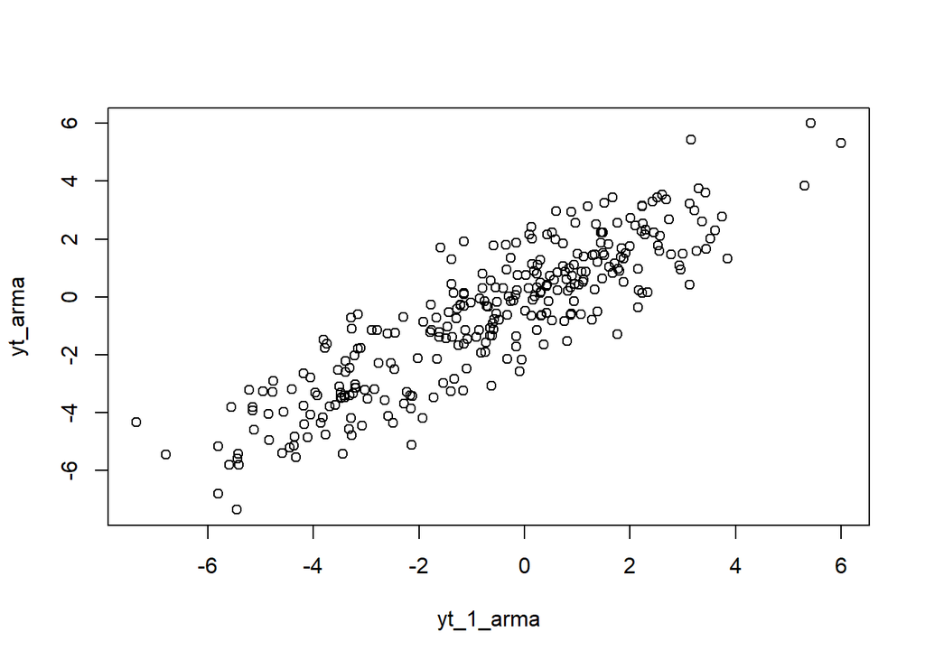

```r
plot(y=yt_arma,x=yt_1_arma)
```

Berdasarkan scatterplot tersebut, terlihat bahwa terdapat hubungan positif antara $Y_t$ dengan $Y_{t-1}$.

```r
cor(yt_arma,yt_1_arma)
```

```
## [1] 0.8790985
```

### Korelasi antara $Y_t$ dengan $Y_{t-2}$

```r
#Yt
yt_arma2 <- arma22[-c(1,2)]
yt_arma2
```

```
##   [1] -3.68397291 -3.78459499 -1.76486417 -1.14397517  1.91652764  1.51207284
##   [7]  3.25772347  1.59698842  1.03347495  0.41909308 -0.54741949  0.31814947
##  [13]  0.17788850  0.89417532  0.72698111  1.06613004 -0.59157560  1.76573525
##  [19] -1.29126987 -0.73696730 -1.91194307 -0.85642922 -1.14822274 -0.32128774
##  [25] -2.15457050 -3.85570013 -4.36109697 -5.14832563 -3.80061204 -1.48817697
##  [31] -1.42912275 -0.53198098 -0.58609755 -1.11797046 -1.15666845 -3.24657941
##  [37] -3.32113466 -4.56798490 -3.96818097 -3.30842671 -2.44470460 -1.24894513
##  [43] -1.66375832 -0.71360665 -0.32322534 -0.61856011 -1.34142389  0.12562937
##  [49]  2.42323477  3.29843009  3.74446076  2.77437022  1.47747344  2.22798858
##  [55]  3.15120117  5.42389536  5.99450882  5.30575978  3.84908134  1.33118863
##  [61]  1.46718023  0.62493128  0.84842223  1.00129482  1.49159068  2.22817697
##  [67]  3.13231500  3.21326048  2.99706341  1.49047322  1.50668145  1.44836578
##  [73]  2.23858297  2.53065410  1.77469041  0.95728526  0.43543817  0.42083327
##  [79]  0.36277033 -1.64892586 -2.13670107 -5.11982638 -4.58146232 -5.40899011
##  [85] -5.80527539 -6.79444276 -5.45352393 -7.35214761 -4.32426725 -5.55123893
```

[output cut: 35 more lines]

```r
#Yt-2
yt_2_arma <- arma22[-c(299,300)]
yt_2_arma
```

```
##   [1] -2.76039543 -2.27741900 -3.68397291 -3.78459499 -1.76486417 -1.14397517
##   [7]  1.91652764  1.51207284  3.25772347  1.59698842  1.03347495  0.41909308
##  [13] -0.54741949  0.31814947  0.17788850  0.89417532  0.72698111  1.06613004
##  [19] -0.59157560  1.76573525 -1.29126987 -0.73696730 -1.91194307 -0.85642922
##  [25] -1.14822274 -0.32128774 -2.15457050 -3.85570013 -4.36109697 -5.14832563
##  [31] -3.80061204 -1.48817697 -1.42912275 -0.53198098 -0.58609755 -1.11797046
##  [37] -1.15666845 -3.24657941 -3.32113466 -4.56798490 -3.96818097 -3.30842671
##  [43] -2.44470460 -1.24894513 -1.66375832 -0.71360665 -0.32322534 -0.61856011
##  [49] -1.34142389  0.12562937  2.42323477  3.29843009  3.74446076  2.77437022
##  [55]  1.47747344  2.22798858  3.15120117  5.42389536  5.99450882  5.30575978
##  [61]  3.84908134  1.33118863  1.46718023  0.62493128  0.84842223  1.00129482
##  [67]  1.49159068  2.22817697  3.13231500  3.21326048  2.99706341  1.49047322
##  [73]  1.50668145  1.44836578  2.23858297  2.53065410  1.77469041  0.95728526
##  [79]  0.43543817  0.42083327  0.36277033 -1.64892586 -2.13670107 -5.11982638
##  [85] -4.58146232 -5.40899011 -5.80527539 -6.79444276 -5.45352393 -7.35214761
```

[output cut: 35 more lines]

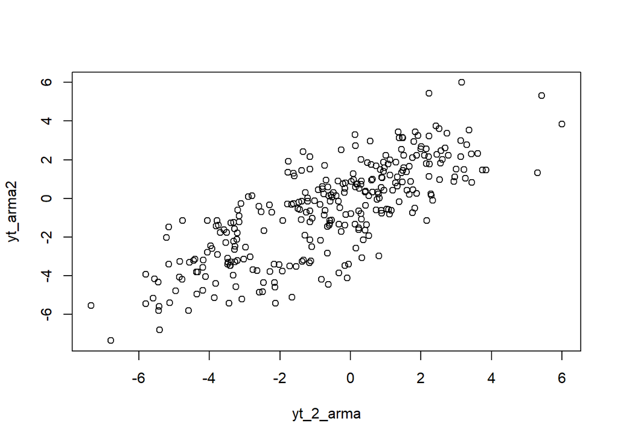

```r
plot(y=yt_arma2,x=yt_2_arma)
```

```r
cor(yt_arma2,yt_2_arma)
```

```
## [1] 0.7839884
```

### Korelasi antara $Y_t$ dengan $Y_{t-3}$

```r
#Yt
yt_arma3 <- arma22[-c(1,2,3)]
yt_arma3
```

```
##   [1] -3.78459499 -1.76486417 -1.14397517  1.91652764  1.51207284  3.25772347
##   [7]  1.59698842  1.03347495  0.41909308 -0.54741949  0.31814947  0.17788850
##  [13]  0.89417532  0.72698111  1.06613004 -0.59157560  1.76573525 -1.29126987
##  [19] -0.73696730 -1.91194307 -0.85642922 -1.14822274 -0.32128774 -2.15457050
##  [25] -3.85570013 -4.36109697 -5.14832563 -3.80061204 -1.48817697 -1.42912275
##  [31] -0.53198098 -0.58609755 -1.11797046 -1.15666845 -3.24657941 -3.32113466
##  [37] -4.56798490 -3.96818097 -3.30842671 -2.44470460 -1.24894513 -1.66375832
##  [43] -0.71360665 -0.32322534 -0.61856011 -1.34142389  0.12562937  2.42323477
##  [49]  3.29843009  3.74446076  2.77437022  1.47747344  2.22798858  3.15120117
##  [55]  5.42389536  5.99450882  5.30575978  3.84908134  1.33118863  1.46718023
##  [61]  0.62493128  0.84842223  1.00129482  1.49159068  2.22817697  3.13231500
##  [67]  3.21326048  2.99706341  1.49047322  1.50668145  1.44836578  2.23858297
##  [73]  2.53065410  1.77469041  0.95728526  0.43543817  0.42083327  0.36277033
##  [79] -1.64892586 -2.13670107 -5.11982638 -4.58146232 -5.40899011 -5.80527539
##  [85] -6.79444276 -5.45352393 -7.35214761 -4.32426725 -5.55123893 -3.81840121
```

[output cut: 35 more lines]

```r
#Yt-1
yt_3_arma <- arma22[-c(298,299,300)]
yt_3_arma
```

```
##   [1] -2.76039543 -2.27741900 -3.68397291 -3.78459499 -1.76486417 -1.14397517
##   [7]  1.91652764  1.51207284  3.25772347  1.59698842  1.03347495  0.41909308
##  [13] -0.54741949  0.31814947  0.17788850  0.89417532  0.72698111  1.06613004
##  [19] -0.59157560  1.76573525 -1.29126987 -0.73696730 -1.91194307 -0.85642922
##  [25] -1.14822274 -0.32128774 -2.15457050 -3.85570013 -4.36109697 -5.14832563
##  [31] -3.80061204 -1.48817697 -1.42912275 -0.53198098 -0.58609755 -1.11797046
##  [37] -1.15666845 -3.24657941 -3.32113466 -4.56798490 -3.96818097 -3.30842671
##  [43] -2.44470460 -1.24894513 -1.66375832 -0.71360665 -0.32322534 -0.61856011
##  [49] -1.34142389  0.12562937  2.42323477  3.29843009  3.74446076  2.77437022
##  [55]  1.47747344  2.22798858  3.15120117  5.42389536  5.99450882  5.30575978
##  [61]  3.84908134  1.33118863  1.46718023  0.62493128  0.84842223  1.00129482
##  [67]  1.49159068  2.22817697  3.13231500  3.21326048  2.99706341  1.49047322
##  [73]  1.50668145  1.44836578  2.23858297  2.53065410  1.77469041  0.95728526
##  [79]  0.43543817  0.42083327  0.36277033 -1.64892586 -2.13670107 -5.11982638
##  [85] -4.58146232 -5.40899011 -5.80527539 -6.79444276 -5.45352393 -7.35214761
```

[output cut: 35 more lines]

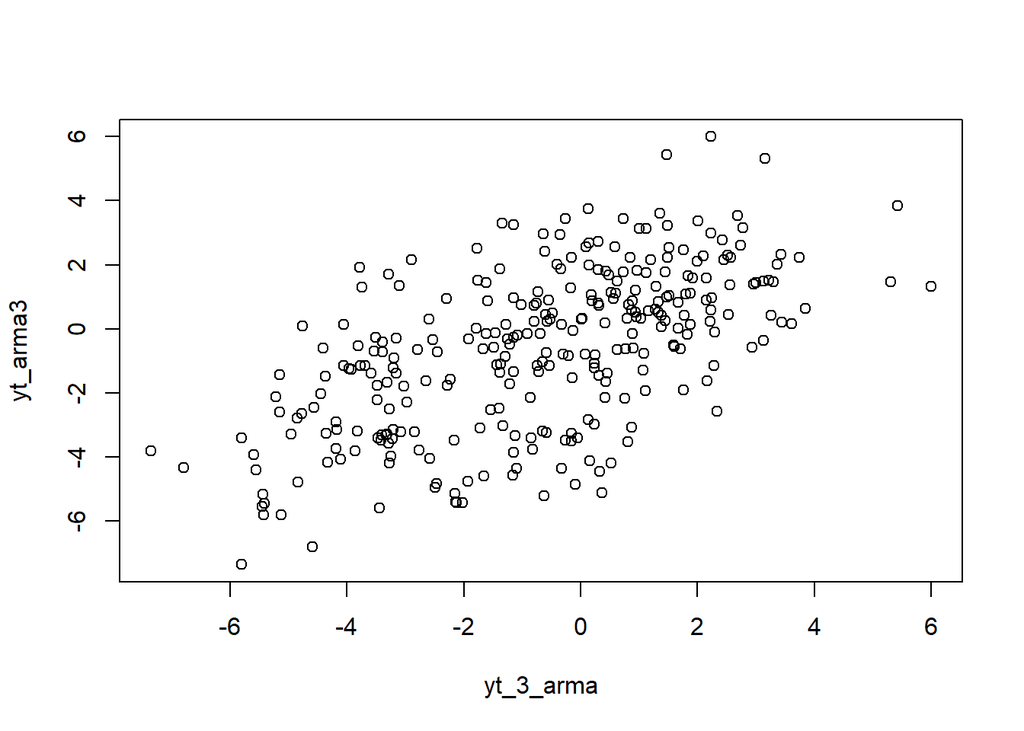

```r
plot(y=yt_arma3,x=yt_3_arma)
```

Berdasarkan scatterplot tersebut, terlihat bahwa terdapat hubungan positif antara $Y_t$ dengan $Y_{t-3}$.

```r
cor(yt_arma3,yt_3_arma)
```

```
## [1] 0.597599
```